# Sampling upper bounds

Ian Osband

October 1, 2015

I want to understand why PSRL and RLSVI outperform UCRL2 so much. One of the most popular theories is that the “rectangular” confidence sets of UCRL2 are very inefficient in large numbers of states and actions. I am going to look into this.

I will look at a very simple example of one unknown transition to one unknown value.

- **PSRL** samples from posterior distribution
- **UCRL** builds up rectangular confidence sets
- **RLSVI** samples from Gaussian approximate posterior

This is the setting of trying to estimate the value of a single state action pair. From this (s,a) we will transition one step according to $P$ and then receive the future value $V$. The model here is that $P$ is drawn from a dirichlet and $V$ from a normal. At the start of the simulations I will make up a fake number of “visits” that indicate how many times we have seen each (s,a) in the future. This will allow us to use the different algorithms and see how they quantify posterior belief.

```r
rm(list=ls())
library(data.table)
library(ggplot2)
library(reshape2)
library(bayesm)
library(knitr)
opts_chunk$set(echo=TRUE, fig.width=10, fig.height=5, cache=FALSE, message=FALSE)


genPSRL <- function(means, visits) {
  # genPSRL makes samples from the PSRL algorithm.
  qNext <- matrix(rnorm(n=length(means), mean=means, sd=1/sqrt(visits)),
                  ncol=ncol(means))
  qMax <- apply(qNext, MARGIN=1, FUN=max)
  alpha <- rowSums(visits)
  pSamp <- rdirichlet(alpha)
  vSamp <- sum(pSamp * qMax)
  return(vSamp)
}

genRLSVI <- function(means, visits) {
  # genRLSVI makes samples from the RLSVI algorithm.
  qNext <- matrix(rnorm(n=length(means), mean=means, sd=1/sqrt(visits)),
                  ncol=ncol(means))
  qMax <- apply(qNext, MARGIN=1, FUN=max)
  alpha <- rowSums(visits)
  pHat <- alpha / sum(alpha)
  vSamp <- sum(pHat * qMax) + rnorm(n=1, sd=1/sqrt(sum(alpha)))
  return(vSamp)
}

genUCRL <- function(means, visits) {
  # genUCRL makes samples from the UCRL algorithm
  qNext <- means + 1 / sqrt(visits)
  qMax <- apply(qNext, MARGIN=1, FUN=max)

  # Now allocate the P-slack optimistically
  nState <- nrow(means)
  slack <- 2 * sqrt(nState / sum(visits))
  pInd <- order(qMax)
  alpha <- rowSums(visits)
  pHat <- alpha / sum(alpha)
  pOpt <- pHat
  if (pOpt[pInd[nState]] + slack * 0.5 > 1) {
    pOpt <- rep(0, nrow(means))
    pOpt[pInd[nState]] <- 1
  } else {
    pOpt[pInd[nState]] <- pOpt[pInd[nState]] + slack * 0.5
  }
  sLoop <- 1
  while (sum(pOpt) > 1) {
    worst <- pInd[sLoop]
    pOpt[worst] <- pmax(0, 1- sum(pOpt) + pOpt[worst])
    sLoop <- sLoop + 1
  }
  vSamp <- sum(pOpt * qMax)
}

comparisonPlot <- function(means, visits) {
  # Generates data and a comparison plot for PSRL, RLSVI, UCRL2
  nSamp <- 1000
  psrl <- rep(NA, nSamp)
  rlsvi <- rep(NA, nSamp)
  for (i in 1:1000) {
    psrl[i] <- genPSRL(means, visits)
    rlsvi[i] <- genRLSVI(means, visits)
  }

  dt <- data.table(psrl=psrl,
                   rlsvi=rlsvi)
  ucrl <- genUCRL(means, visits)
  plt <- (ggplot(melt(dt, measure.vars=c('psrl', 'rlsvi')))
          + aes(x=value, colour=variable)
          + geom_vline(xintercept=ucrl)
          + geom_text(x=ucrl, y=1, label='UCRL', colour='black', angle=90, vjust=-0.5)
          + geom_density()
          + ggtitle('Learning bounds')
          + xlab('Estimated value')
          + ylab('Density'))
  return(plt)
}
```

### Small problem (S=5, A=5)

#### Few visits

```r
set.seed(0)

nState <- 5
nAction <- 5
means <- matrix(rnorm(nState*nAction), ncol=nAction)
visits <- matrix(rbinom(n=nState*nAction, size=10, prob=0.1) + 1,
                 ncol=nAction)
print(visits)
```

```
##      [,1] [,2] [,3] [,4] [,5]
## [1,]    2    1    2    2    3
## [2,]    2    1    3    1    1
## [3,]    3    1    1    2    3
## [4,]    2    2    2    3    1
## [5,]    1    2    1    1    1
```

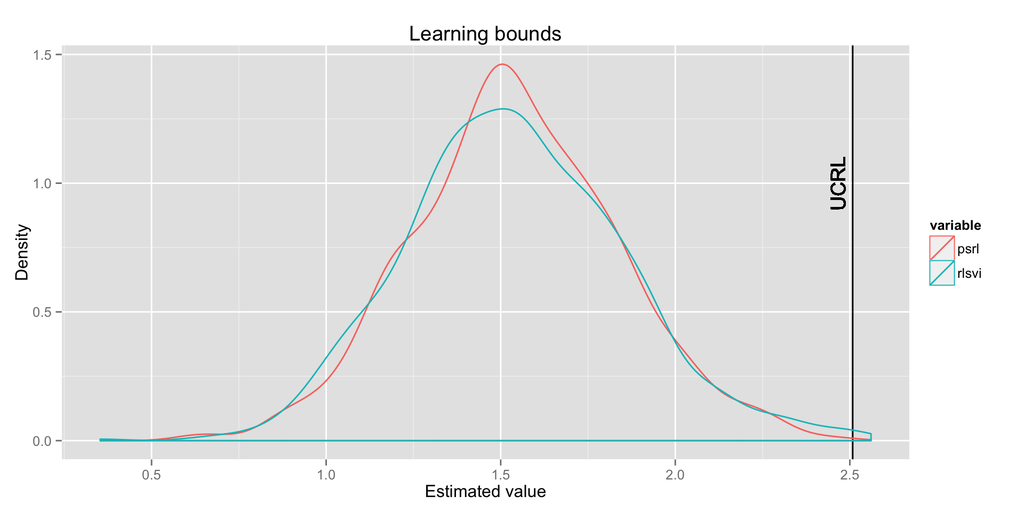

```r
plt <- comparisonPlot(means, visits)
plt
```

#### Skewed visits

```r
visits <- matrix(100 * rbinom(n=nState*nAction, size=20, prob=0.1) + 1,
                 ncol=nAction)
print(visits)
```

```
##      [,1] [,2] [,3] [,4] [,5]
## [1,]  101  301  201  101  201
## [2,]  101  501  201  101  101
## [3,]  101  101  301  201  301
## [4,]  301  301  101    1  301
## [5,]    1  301  201  401  401
```

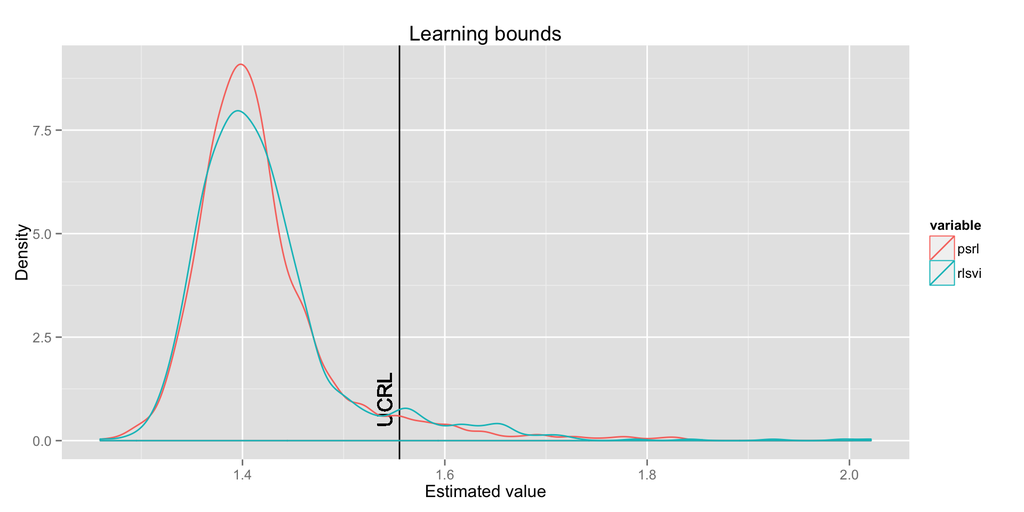

```r
plt <- comparisonPlot(means, visits)
plt
```

#### Many visits

```r
visits <- matrix(rbinom(n=nState*nAction, size=20, prob=0.1) + 10,
                 ncol=nAction) * 100
print(visits)
```

```
##      [,1] [,2] [,3] [,4] [,5]
## [1,] 1000 1300 1000 1100 1100
## [2,] 1300 1200 1200 1200 1300
## [3,] 1200 1600 1000 1200 1100
## [4,] 1300 1100 1200 1100 1200
## [5,] 1200 1100 1100 1900 1100
```

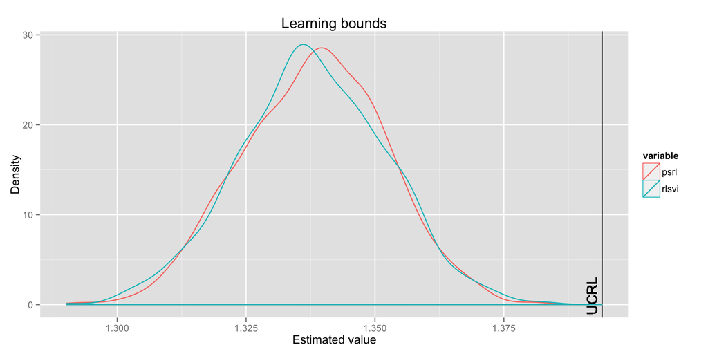

```r
plt <- comparisonPlot(means, visits)
plt
```

### Bigger problem (S=100, A=5)

#### Few visits

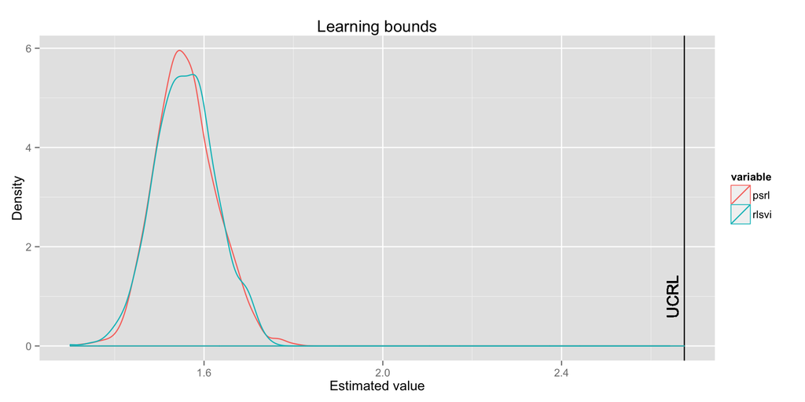

```r
nState <- 100
nAction <- 5
means <- matrix(rnorm(nState*nAction), ncol=nAction)
visits <- matrix(rbinom(n=nState*nAction, size=10, prob=0.1) + 1,
                 ncol=nAction)
# print(visits)
plt <- comparisonPlot(means, visits)
plt
```

#### Skewed visits

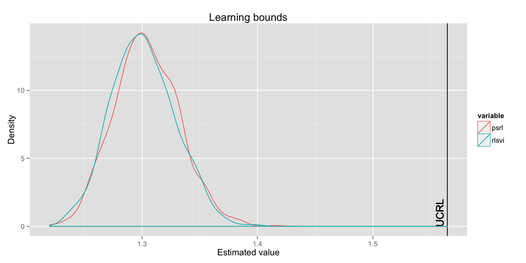

```r
visits <- matrix(100 * rbinom(n=nState*nAction, size=20, prob=0.1) + 1,
                 ncol=nAction)
# print(visits)
plt <- comparisonPlot(means, visits)
plt
```

#### Many visits

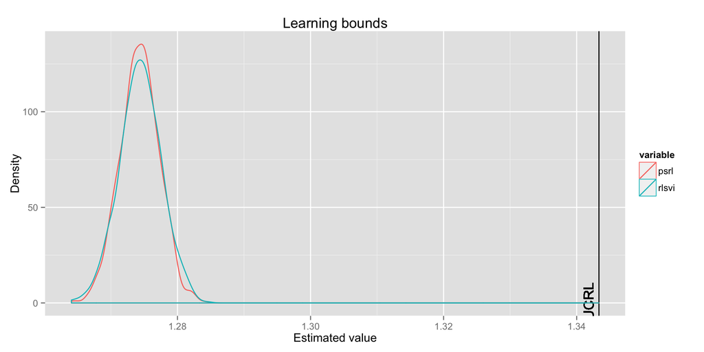

```r
visits <- matrix(rbinom(n=nState*nAction, size=20, prob=0.1) + 10,
                 ncol=nAction) * 100
# print(visits)
plt <- comparisonPlot(means, visits)
plt
```

## Huge problem (S=1000, A=5)

#### Few visits

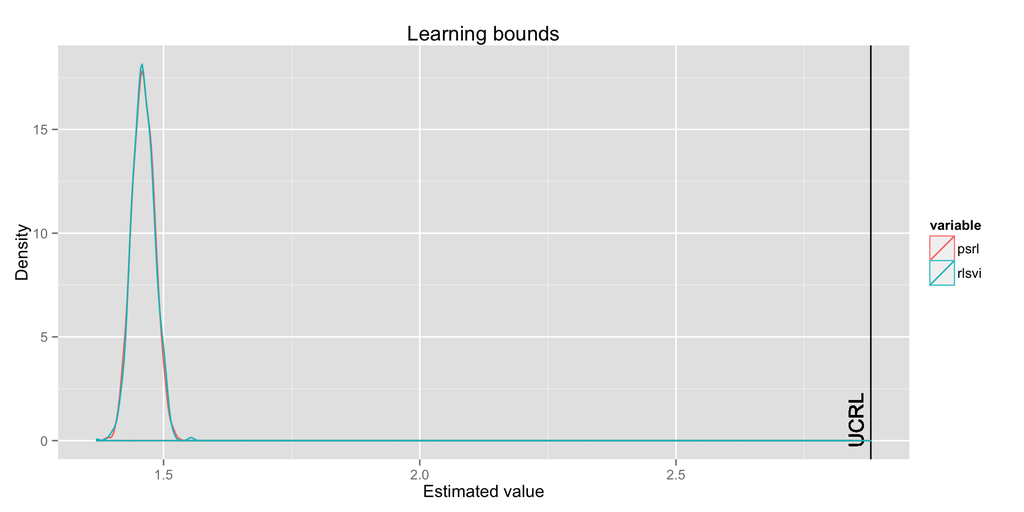

```r
nState <- 1000
nAction <- 5
means <- matrix(rnorm(nState*nAction), ncol=nAction)
visits <- matrix(rbinom(n=nState*nAction, size=10, prob=0.1) + 1,
                 ncol=nAction)
# print(visits)
plt <- comparisonPlot(means, visits)
plt
```

#### Skewed visits

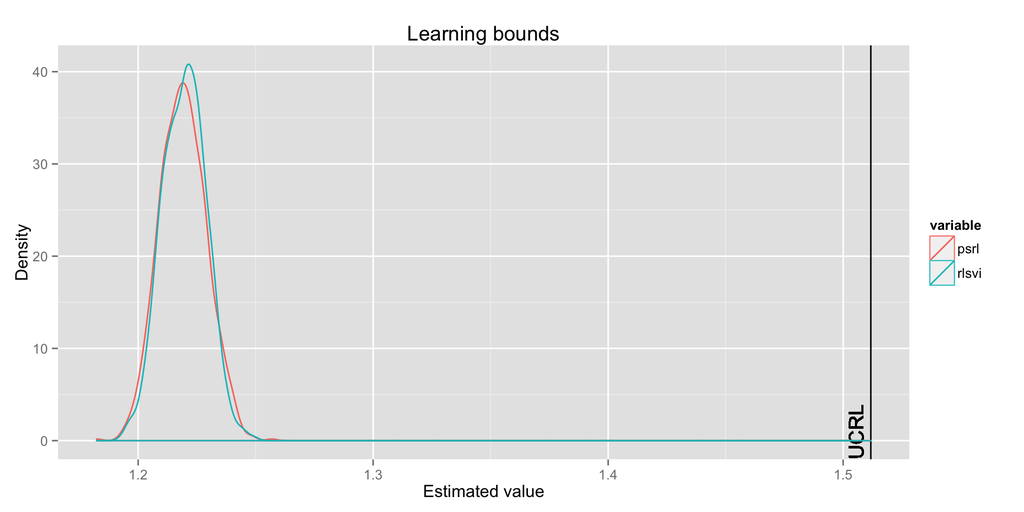

```r
visits <- matrix(100 * rbinom(n=nState*nAction, size=20, prob=0.1) + 1,
                 ncol=nAction)
# print(visits)
plt <- comparisonPlot(means, visits)
plt
```

#### Many visits

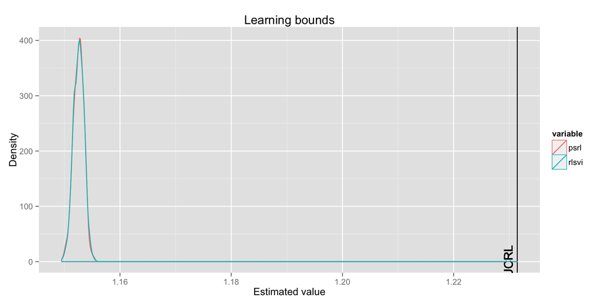

```r
visits <- matrix(rbinom(n=nState*nAction, size=20, prob=0.1) + 10,
                 ncol=nAction) * 100
# print(visits)
plt <- comparisonPlot(means, visits)
plt
```

## So what?

Here we can see very clearly that RLSVI and PSRL are essentially the same in terms of their value estimates. UCRL2 still converges, but we can see this rectangular confidence set is a big problem, particularly in settings with a high number of states and actions.

> Better UCB via posterior sampling

Overall I’m massively for posterior sampling, but there might be some other examples where specifically using optimism is useful. Maybe if we’re risk-averse or using some type of monte-carlo tree search. It seems like, even in this setting, you’d do much much better building your UCB via an RLSVI-style simulation rather than direct rectangular analysis.